# Final Assignment: Roman Emperors

Rebeka Zsoldos

## Background

According to wikipedia:

The Roman emperor was the ruler of the Roman Empire during the imperial period (starting in 27 BC). The emperors used a variety of different titles throughout history. Often when a given Roman is described as becoming “emperor” in English, it reflects his taking of the title Augustus or Caesar. Another title often used was imperator, originally a military honorific. Early emperors also used the title Princeps Civitatis (‘first citizen’). Emperors frequently amassed republican titles, notably princeps senatus, consul, and pontifex maximus.

The legitimacy of an emperor’s rule depended on his control of the army and recognition by the Senate; an emperor would normally be proclaimed by his troops, or invested with imperial titles by the Senate, or both. The first emperors reigned alone; later emperors would sometimes rule with co-emperors and divide administration of the empire between them.

The Romans considered the office of emperor to be distinct from that of a king. The first emperor, Augustus, resolutely refused recognition as a monarch.[1] For the first three hundred years of Roman emperors, from Augustus until Diocletian, efforts were made to portray the emperors as leaders of the republic, fearing any association with the kings of Rome prior to the Republic.

From Diocletian, whose tetrarchic reforms also divided the position into one emperor in the West and one in the East, until the end of the Empire, emperors ruled in an openly monarchic style[2] and did not preserve the nominal principle of a republic, but the contrast with “kings” was maintained: although the imperial succession was generally hereditary, it was only hereditary if there was a suitable candidate acceptable to the army and the bureaucracy,[3] so the principle of automatic inheritance was not adopted. Elements of the republican institutional framework (senate, consuls, and magistrates) were preserved even after the end of the Western Empire. (https://en.wikipedia.org/wiki/Roman_emperor)

## Importing Data

```r
#read data
emperors_raw <- readr::read_csv(url("https://raw.githubusercontent.com/rfordatascience/tidytuesday/master/data/2019/2019-08-13/emperors.csv"), na = c("NA", "Unknown"))
```

## Cleaning the Data

```r
emperors <- emperors_raw %>%
  mutate(
    birth_cty = as.factor(birth_cty),
    birth_prv = as.factor(birth_prv),
    #relevel the factors
    rise = fct_relevel(rise,
                            "Seized Power", "Appointment by Army", "Appointment by Praetorian Guard", "Purchase",
                            "Election", "Appointment by Senate", "Appointment by Emperor", "Birthright"),
     #relevel the cause of death
    cause = fct_relevel(cause,
                             "Natural Causes", "Assassination", "Execution",  "Suicide", "Died in Battle",
                              "Captivity"),
    killer = as.factor(killer),
    dynasty = as.factor(dynasty),
    era = as.factor(era)
           ) %>%
  select(-name_full, -notes, - verif_who) %>%
#As the dataset contains BC years so it is necessary to recode them for further computations
#Firstly set the dates to years only
  mutate(
    birth_year = as.numeric(format(birth, '%Y')),
    death_year = as.numeric(format(death, '%Y')),
    reign_start_year = as.numeric(format(reign_start, '%Y')),
    reign_end_year = as.numeric(format(reign_end, '%Y'))) %>%
#Recoding BC years as negative numbers and AC years as positive numbers
#If the birth year or the starting year of the reign is higher then the year of the death/the end of reign, then that year must be BC
  mutate(
    birth_year = ifelse(birth_year > death_year, (birth_year * -1), (birth_year * 1)),
    reign_start_year = ifelse(reign_start_year > reign_end_year, (reign_start_year * -1), (reign_start_year * 1)),
    age_reign_start = reign_start_year - birth_year,
    age_reign_end = reign_end_year - birth_year,
#The length of the reign in years
    reign_long_year = reign_end_year - reign_start_year,
#Which century did the emperor rule?
    century = reign_end_year %/% 100 + 1)
```

## EDA

### How rulers came to power and lost it

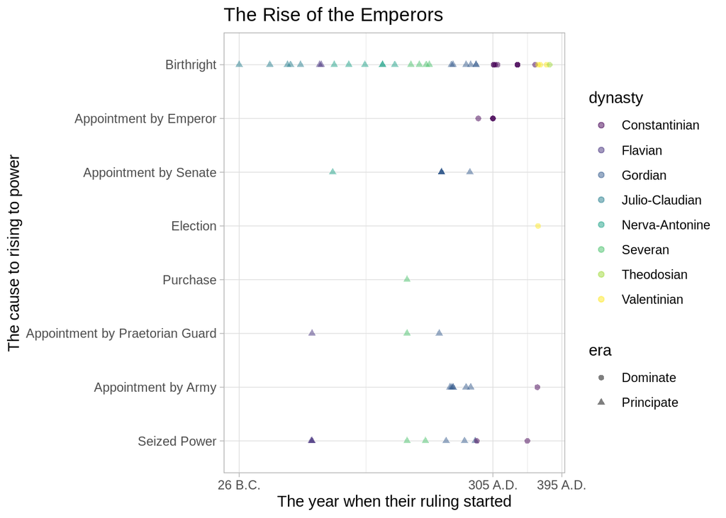

```r
#Putting the emperors on a timeline, based on the fact how they rose to power and which dynasty they did belong
rise_emperors <- ggplot(emperors, aes(reign_start_year, rise, color = dynasty, shape = era)) +
  geom_point(alpha = 0.5) +
  scale_x_continuous(breaks = c(-26, 305, 395),
                   labels = c("26 B.C.", "305 A.D.", "395 A.D.")) +
  xlab("The year when their ruling started") +
  ylab("The cause to rising to power") +
  labs(title = "The Rise of the Emperors") +
  scale_color_viridis_d()

rise_emperors
```

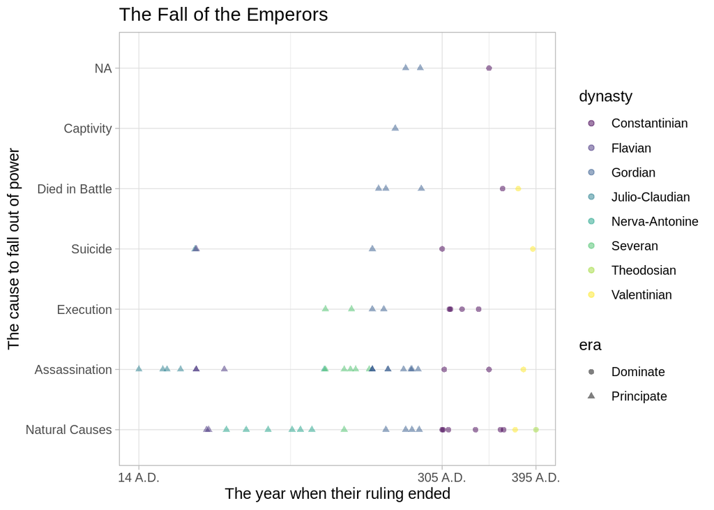

```r
#Putting the emperors on a timeline, based on the fact how they fell out of power and which dynasty they did belong
fall_emperors <- emperors %>%
  ggplot(aes(reign_end_year, cause, color = dynasty, shape = era)) +
  geom_point(alpha = 0.5) +
  scale_x_continuous(breaks = c(14, 305, 395),
                   labels = c("14 A.D.", "305 A.D.", "395 A.D.")) +
  xlab("The year when their ruling ended") +
  ylab("The cause to fall out of power") +
  labs(title = "The Fall of the Emperors") +
  scale_color_viridis_d()

fall_emperors
```

The emperors came to power mostly by birthright and died of natural causes or were the victims of assassination.

### How long the reign of the emperors lasted and how it ended

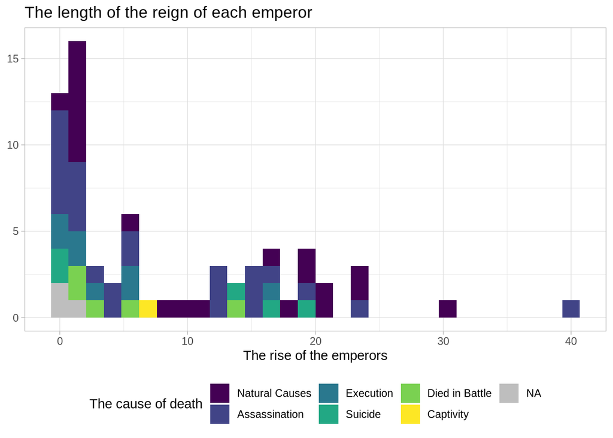

```r
#Exploring the frequency of the lengths of the reigns
reign_length_emperors <- emperors %>%
  ggplot(aes(reign_long_year, fill = cause)) +
  geom_histogram() +
  theme(legend.position = "bottom") +
  xlab("The rise of the emperors") +
  ylab(NULL) +
  labs(title = "The length of the reign of each emperor") +
  scale_fill_viridis(discrete = TRUE, na.value = "grey", name = "The cause of death")

reign_length_emperors
```

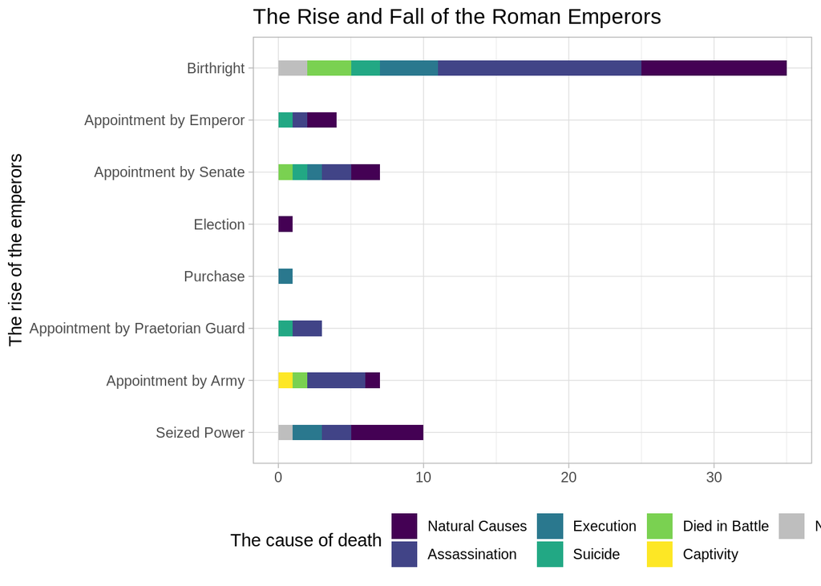

```r
#Exploring how the emperors died categorized by their rise to power
rise_and_fall2 <- emperors %>%
  ggplot(aes(rise, fill = cause)) +
  geom_bar(width = 0.3) +
  coord_flip() +
  theme(legend.position = "bottom") +
  xlab("The rise of the emperors") +
  ylab(NULL) +
  labs(title = "The Rise and Fall of the Roman Emperors") +
  scale_fill_viridis(discrete = TRUE, na.value = "grey", name = "The cause of death")

rise_and_fall2
```

Many emperors ruled for only one or two years, and those who came to power by birthright may also have been assassinated.

### How old were the emperors when they came to power?

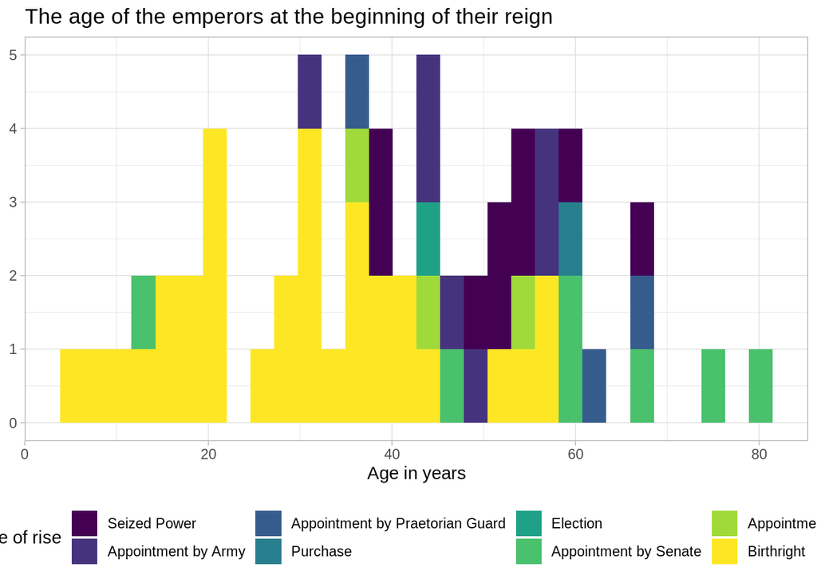

```r
#Exploring the frequency of the ages of the emperors at the beginning of their reign
age_rise_emperors <- emperors %>%
  ggplot(aes(age_reign_start, fill = rise)) +
  geom_histogram() +
  theme(legend.position = "bottom") +
  xlab("Age in years") +
  ylab(NULL) +
  labs(title = "The age of the emperors at the beginning of their reign") +
  scale_fill_viridis(discrete = TRUE, na.value = "grey", name = "The cause of rise")

age_rise_emperors
```

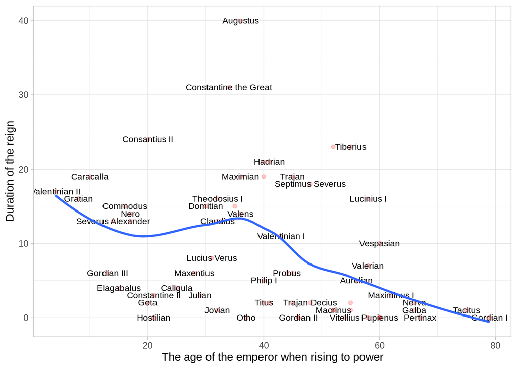

```r
#calculate the mean when the emperors rose to power
mean_age_reign_start <- mean(emperors$age_reign_start, na.rm = TRUE)

#calculate SD
sd_age_reign_start <- sd(emperors$age_reign_start, na.rm = TRUE)


#Exploring how the age of the emperors at the beginning of their reign relates to the duration of their reign
age_and_long <- emperors %>%
  ggplot(aes(age_reign_start, reign_long_year)) +
  geom_point(alpha = 0.2, color = "red") +
  geom_text(aes(label = name), size= 3, check_overlap = TRUE) +
  geom_smooth(se = FALSE) +
  theme(legend.position = "bottom", legend.title = element_blank()) +
  xlab("The age of the emperor when rising to power") +
  ylab("Duration of the reign") +
  scale_color_viridis(discrete = TRUE, na.value = "grey")

age_and_long
```

Average age at which rulers came to power was 40.6507937 years (SD: 17.5537504). Those who came to the throne when they were old ruled for shorter periods.